# Report of exercise 4

My learning this week: Clustering and LDA were quite unfamiliar to me beforehand. I think I gained some (initial) understanding of them, but it is also possible that some parts of these methods demand more studying. As a useful detail from this week I will take with me the corrplots, which I found to be a very illustrative way to visualize the correlations between a group of variables.

The Boston data was quite difficult to interpret since the variables were somewhat ambiguous to me (as I am not a economist or a sovial scientist).

Below I present my report of the work performed this week.

## Exploration the data

First, I access the relevat libraries and take a look at the Boston data.

```r
library(MASS)
library(corrplot)
library(dplyr)
library (ggplot2)
data(Boston)
str(Boston)
```

```
## 'data.frame':    506 obs. of  14 variables:
##  $ crim   : num  0.00632 0.02731 0.02729 0.03237 0.06905 ...
##  $ zn     : num  18 0 0 0 0 0 12.5 12.5 12.5 12.5 ...
##  $ indus  : num  2.31 7.07 7.07 2.18 2.18 2.18 7.87 7.87 7.87 7.87 ...
##  $ chas   : int  0 0 0 0 0 0 0 0 0 0 ...
##  $ nox    : num  0.538 0.469 0.469 0.458 0.458 0.458 0.524 0.524 0.524 0.524 ...
##  $ rm     : num  6.58 6.42 7.18 7 7.15 ...
##  $ age    : num  65.2 78.9 61.1 45.8 54.2 58.7 66.6 96.1 100 85.9 ...
##  $ dis    : num  4.09 4.97 4.97 6.06 6.06 ...
##  $ rad    : int  1 2 2 3 3 3 5 5 5 5 ...
##  $ tax    : num  296 242 242 222 222 222 311 311 311 311 ...
##  $ ptratio: num  15.3 17.8 17.8 18.7 18.7 18.7 15.2 15.2 15.2 15.2 ...
##  $ black  : num  397 397 393 395 397 ...
##  $ lstat  : num  4.98 9.14 4.03 2.94 5.33 ...
##  $ medv   : num  24 21.6 34.7 33.4 36.2 28.7 22.9 27.1 16.5 18.9 ...
```

```r
dim(Boston)
```

```
## [1] 506  14
```

The Boston data has 506 observations (= suburbs) and 14 variables, which are type ‘numeric’ or ‘integer’. The variables of the data contain information about housing in suburbs of Boston, e.g. crime rates, accessibility, economical details, pupil-teacher ratio etc.

Next, let’s explore tha data visually.

```r
par(fmrow = c(2,2))
```

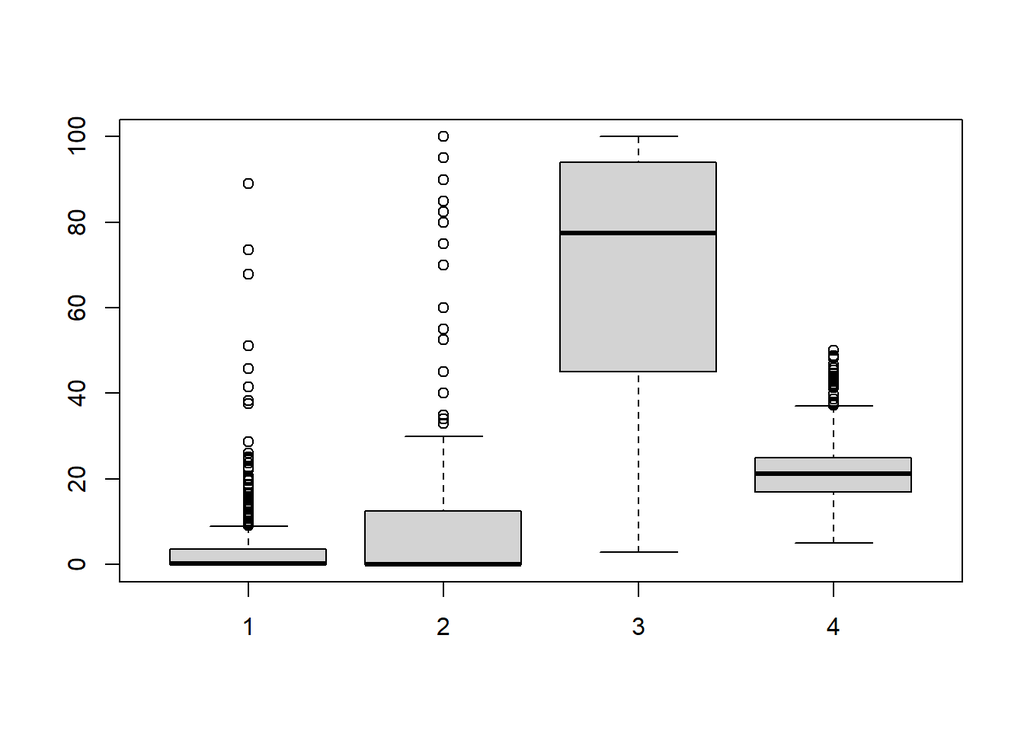

```r
boxplot(Boston$crim, Boston$zn, Boston$age, Boston$medv)
```

```r
par(fmrow = c(2,3))
```

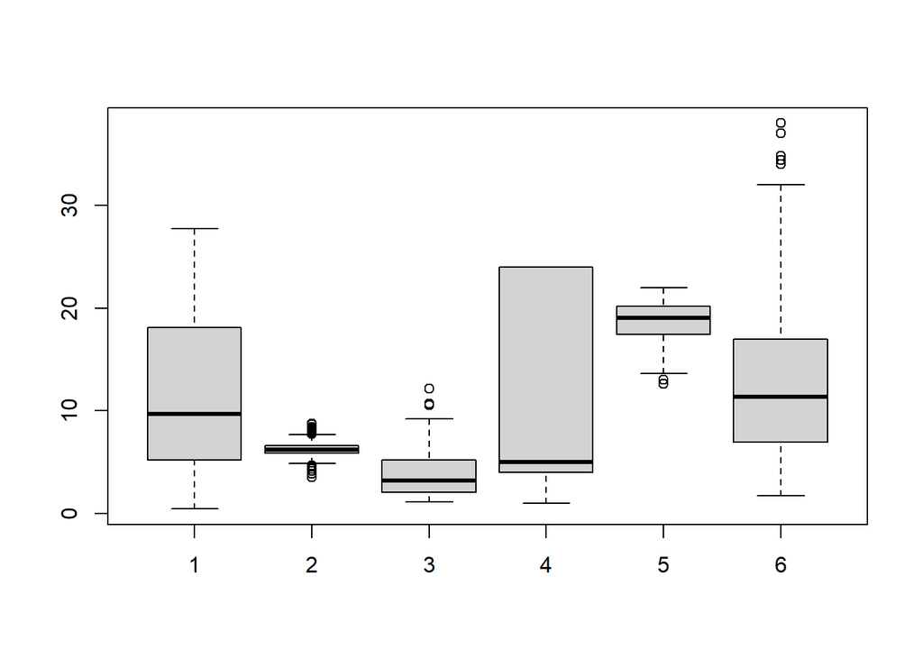

```r
boxplot(Boston$indus, Boston$rm, Boston$dis, Boston$rad, Boston$ptratio, Boston$lstat)
```

```r
par(fmrow = c(1,2))
```